# Acheta Desiccation

## 7.1 Plot: Total lipids

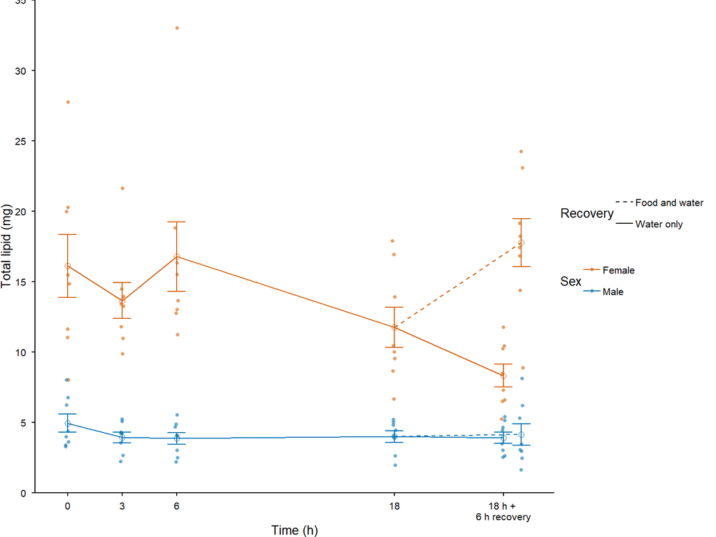

```r
p_total_lipids <- ggplot() +
  geom_point(data = lipid_data, aes(Time_plot, total_lipid, shape = Sex, colour = Sex), position = position_jitter(width = 0.1, height = 0), alpha = 0.6, stroke = NA) +
   # line for starved crickets
  geom_line(data = mean_total_starved_l, aes(Time_plot, mean, colour = Sex, linetype = "Starved"), linewidth = 0.5) +
   # Line for fed crickets
  geom_line(data = mean_total_fed_l, aes(Time_plot, mean, colour = Sex, linetype = "Fed"), linewidth = 0.5) +
  geom_point(data = mean_total_lipid, aes(Time_plot, mean, colour = Sex),
             size = 2, shape = 1, show.legend = FALSE) +
  geom_errorbar(data = mean_total_lipid, aes(Time_plot, ymin = mean - se, ymax = mean + se,
                                     colour = Sex), width = 1, linewidth = 0.5) +
  scale_colour_manual(values = sex_pal) +
  scale_shape_manual(values = sex_point) +
  scale_linetype_manual(name = "Recovery", values = c("Fed" = 2, "Starved" = 1), labels = c("Food and water", "Water only")) +
  scale_y_continuous(name = "Total lipid (mg)", limits = c(0, 35), expand = c(0,0), breaks = seq(0, 100, 5)) +
  scale_x_continuous(name = "Time (h)", breaks = c(0, 3, 6, 18, 24), labels = c("0", "3", "6", "18", "18 h + \n6 h recovery")) +
  theme(legend.position = "right")

p_total_lipids
```

## 7.2 Plot: mg lipid per mg dry mass

```r
mean_lipid <- lipid_data %>%
  group_by(Time_treatment, Sex, Time, Time_plot) %>%
  drop_na(mg_lipid_per_mg_tissue) %>%
  summarise(n = n(),
            mean = mean(mg_lipid_per_mg_tissue),
            var = var(mg_lipid_per_mg_tissue),
            se = sd(mg_lipid_per_mg_tissue) / sqrt(n()),
            cv = (sd(mg_lipid_per_mg_tissue) / mean) * 100)
knitr::kable(mean_lipid, digits = 3)
```

| Time_treatment | Sex | Time | Time_plot | n | mean | var | se | cv |
| --- | --- | --- | --- | --- | --- | --- | --- | --- |
| 0 | Female | 0 | 0 | 8 | 0.073 | 0 | 0.004 | 16.629 |
| 0 | Male | 0 | 0 | 8 | 0.059 | 0 | 0.007 | 33.383 |
| 3 | Female | 3 | 3 | 8 | 0.069 | 0 | 0.005 | 19.060 |
| 3 | Male | 3 | 3 | 8 | 0.050 | 0 | 0.003 | 16.754 |
| 6 | Female | 6 | 6 | 8 | 0.072 | 0 | 0.006 | 24.916 |
| 6 | Male | 6 | 6 | 8 | 0.051 | 0 | 0.004 | 21.239 |
| 18 | Female | 18 | 18 | 8 | 0.070 | 0 | 0.005 | 21.936 |
| 18 | Male | 18 | 18 | 8 | 0.054 | 0 | 0.003 | 16.813 |
| 24_fed | Female | 24 | 25 | 8 | 0.069 | 0 | 0.006 | 22.559 |
| 24_fed | Male | 24 | 25 | 8 | 0.039 | 0 | 0.006 | 40.448 |
| 24_starved | Female | 24 | 24 | 8 | 0.055 | 0 | 0.004 | 19.223 |
| 24_starved | Male | 24 | 24 | 8 | 0.048 | 0 | 0.005 | 27.342 |

```r
mean_lipid_starved <- filter(mean_lipid, Time_treatment != "24_fed")
mean_lipid_fed <- filter(mean_lipid, Time_treatment %in% c("18", "24_fed"))
```

> Coefficients of variation are similarly high for all treatments. No reason to suspect one group is biased.

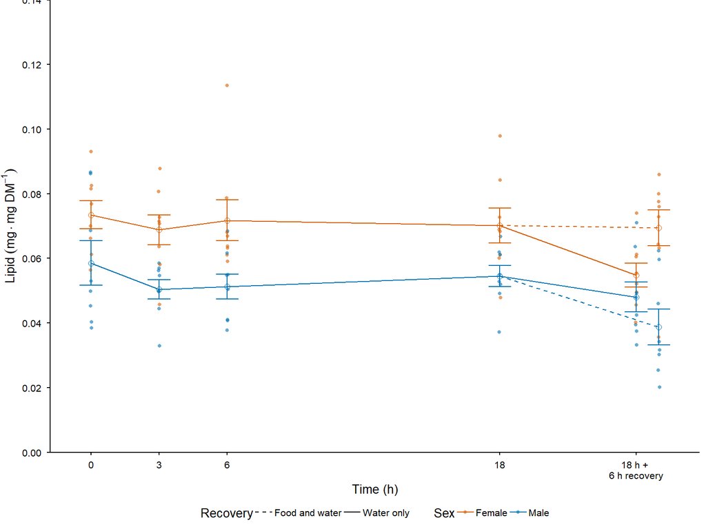

```r
p_lipid <- ggplot() +
  geom_point(data = lipid_data, aes(Time_plot, mg_lipid_per_mg_tissue, shape = Sex, colour = Sex, group = Time_treatment), position = position_jitterdodge(jitter.width = 0.1, jitter.height = 0, dodge = 0), alpha = 0.6, stroke = NA) +
  # line for starved crickets
  geom_line(data = mean_lipid_starved, aes(Time_plot, mean, colour = Sex, linetype = "Starved"), linewidth = 0.5) +
  # Line for fed crickets
  geom_line(data = mean_lipid_fed, aes(Time_plot, mean, colour = Sex, linetype = "Fed"), linewidth = 0.5) +
  geom_point(data = mean_lipid, aes(Time_plot, mean, colour = Sex, group = Time_treatment),
             size = 2, shape = 1, show.legend = FALSE) +
  geom_errorbar(data = mean_lipid, aes(Time_plot, ymin = mean - se, ymax = mean + se,
                                     colour = Sex), width = 1, linewidth = 0.5) +
  scale_colour_manual(values = sex_pal) +
  scale_shape_manual(values = sex_point) +
  scale_linetype_manual(name = "Recovery", values = c("Fed" = 2, "Starved" = 1), labels = c("Food and water", "Water only")) +
  scale_y_continuous(name = expression("Lipid" ~ ("mg"%.%"mg DM"^-1)), limits = c(0, 0.14), expand = c(0,0), breaks = seq(0, 100, 0.02)) +
  scale_x_continuous(name = "Time (h)", breaks = c(0, 3, 6, 18, 24), labels = c("0", "3", "6", "18", "18 h + \n6 h recovery"))

p_lipid
```

```r
ggsave(p_lipid, dpi = 300, width = ppt_width, units = "mm", height = ppt_height, filename = "data/Desiccation 2025/figures/tissue_lipids.png")
```

## 7.3 Stats: Total lipids

- Three way interaction dropped
- Plate effect not significant, kept.
- F 18 vs 24 starved different

```r
full_l_mod <- lmer(total_lipid ~ Start_mass * Time_treatment * Sex + (1|Plate), data = lipid_data, REML = FALSE)

anova(full_l_mod)
```

```
Type III Analysis of Variance Table with Satterthwaite's method
                               Sum Sq Mean Sq NumDF  DenDF F value
Start_mass                    200.568 200.568     1 89.022 57.9197
Time_treatment                 26.137   5.227     5 92.905  1.5095
Sex                            17.594  17.594     1 93.744  5.0808
Start_mass:Time_treatment      12.998   2.600     5 92.151  0.7507
Start_mass:Sex                 16.219  16.219     1 92.511  4.6836
Time_treatment:Sex             26.979   5.396     5 90.926  1.5582
Start_mass:Time_treatment:Sex  12.182   2.436     5 91.213  0.7036
                                        Pr(>F)
Start_mass                    0.00000000002712 ***
Time_treatment                         0.19438
Sex                                    0.02652 *
Start_mass:Time_treatment              0.58766
Start_mass:Sex                         0.03303 *
Time_treatment:Sex                     0.17991
Start_mass:Time_treatment:Sex          0.62219
---
Signif. codes:  0 '***' 0.001 '**' 0.01 '*' 0.05 '.' 0.1 ' ' 1
```

```r
# Three way interaction is not significant

total_l_mod <- update(full_l_mod, .~. - Start_mass:Time_treatment:Sex)

best_l_mod <- step(full_l_mod)
print(best_l_mod)
```

```
Backward reduced random-effect table:

            Eliminated npar  logLik    AIC    LRT Df Pr(>Chisq)
<none>                   26 -199.52 451.05
(1 | Plate)          0   25 -200.99 451.99 2.9419  1    0.08631 .
---
Signif. codes:  0 '***' 0.001 '**' 0.01 '*' 0.05 '.' 0.1 ' ' 1

Backward reduced fixed-effect table:
Degrees of freedom method: Satterthwaite

                              Eliminated Sum Sq Mean Sq NumDF  DenDF F value
Start_mass:Time_treatment:Sex          1 12.182  2.4363     5 91.213  0.7036
Start_mass:Time_treatment              0 50.316 10.0633     5 90.789  2.7822
Start_mass:Sex                         0 19.188 19.1878     1 91.767  5.3049
Time_treatment:Sex                     0 45.670  9.1339     5 91.918  2.5253
                               Pr(>F)
Start_mass:Time_treatment:Sex 0.62219
Start_mass:Time_treatment     0.02199 *
Start_mass:Sex                0.02352 *
Time_treatment:Sex            0.03450 *
---
Signif. codes:  0 '***' 0.001 '**' 0.01 '*' 0.05 '.' 0.1 ' ' 1

Model found:
total_lipid ~ Start_mass + Time_treatment + Sex + (1 | Plate) + Start_mass:Time_treatment + Start_mass:Sex + Time_treatment:Sex
```

```r
# Model selection drops three way interaction
# Random term is not significant but keeps term

anova(total_l_mod)
```

```
Type III Analysis of Variance Table with Satterthwaite's method
                           Sum Sq Mean Sq NumDF  DenDF F value
Start_mass                229.464 229.464     1 90.730 63.4406
Time_treatment             49.925   9.985     5 92.218  2.7606
Sex                        20.157  20.157     1 92.330  5.5728
Start_mass:Time_treatment  50.316  10.063     5 90.789  2.7822
Start_mass:Sex             19.188  19.188     1 91.767  5.3049
Time_treatment:Sex         45.670   9.134     5 91.918  2.5253
                                     Pr(>F)
Start_mass                0.000000000004601 ***
Time_treatment                      0.02275 *
Sex                                 0.02035 *
Start_mass:Time_treatment           0.02199 *
Start_mass:Sex                      0.02352 *
Time_treatment:Sex                  0.03450 *
---
Signif. codes:  0 '***' 0.001 '**' 0.01 '*' 0.05 '.' 0.1 ' ' 1
```

```r
pairs(emmeans(total_l_mod, ~ Time_treatment * Sex), adjust = "Tukey", by = "Sex") %>%
  broom::tidy() |>
  filter(adj.p.value <= 0.05)
```

```
# A tibble: 1 × 9
  Sex    term           contrast        null.value estimate std.error       df
  <chr>  <chr>          <chr>                <dbl>    <dbl>     <dbl>    <dbl>
1 Female Time_treatment 18 - 24_starved          0 4.967741  1.579181 119.4376
  statistic adj.p.value
      <dbl>       <dbl>
1  3.145771  0.02494240
```

## 7.4 Stats: Lipid per dry mass

```r
lipid_mod <- lmer(mg_lipid_per_mg_tissue ~ Time_treatment + Sex + (1|Plate), lipid_data)
anova(lipid_mod)
```

```
Type III Analysis of Variance Table with Satterthwaite's method
                  Sum Sq   Mean Sq NumDF DenDF F value           Pr(>F)
Time_treatment 0.0019250 0.0003850     5 26.12  2.3697          0.06712 .
Sex            0.0088446 0.0088446     1 86.01 54.4392 0.00000000009396 ***
---
Signif. codes:  0 '***' 0.001 '**' 0.01 '*' 0.05 '.' 0.1 ' ' 1
```

```r
pairs(emmeans(lipid_mod, ~ Time_treatment), adjust = "Tukey") %>%
  broom::tidy()
```

```
# A tibble: 15 × 8
   term           contrast            null.value      estimate   std.error
   <chr>          <chr>                    <dbl>         <dbl>       <dbl>
 1 Time_treatment 0 - 3                        0  0.005386933  0.004745022
 2 Time_treatment 0 - 6                        0  0.007024917  0.004637781
 3 Time_treatment 0 - 18                       0  0.004784731  0.004556358
 4 Time_treatment 0 - 24_fed                   0  0.01170943   0.009053395
 5 Time_treatment 0 - 24_starved               0  0.01526903   0.004624318
 6 Time_treatment 3 - 6                        0  0.001637984  0.004916385
 7 Time_treatment 3 - 18                       0 -0.0006022019 0.004653349
 8 Time_treatment 3 - 24_fed                   0  0.006322501  0.009116318
 9 Time_treatment 3 - 24_starved               0  0.009882102  0.004803117
10 Time_treatment 6 - 18                       0 -0.002240186  0.004606930
11 Time_treatment 6 - 24_fed                   0  0.004684517  0.009093495
12 Time_treatment 6 - 24_starved               0  0.008244118  0.004717873
```

[output cut: 20 more lines]

```r
emmeans(lipid_mod, ~ Time_treatment) %>%
  contrast(method = "trt.vs.ctrl", ref = 1)
```

```
 contrast       estimate      SE    df t.ratio p.value
 3 - 0          -0.00539 0.00475 87.14  -1.135  0.6541
 6 - 0          -0.00702 0.00464 86.15  -1.515  0.4161
 18 - 0         -0.00478 0.00456 85.14  -1.050  0.7067
 24_fed - 0     -0.01171 0.00905  4.97  -1.293  0.6059
 24_starved - 0 -0.01527 0.00462 86.76  -3.302  0.0065

Results are averaged over the levels of: Sex
Degrees-of-freedom method: kenward-roger
P value adjustment: dunnettx method for 5 tests
```

**Mixed effects model: Plate as a random effect**

- No interaction
- No main effect of time - only between 0 and 24 (starved)

# 8 Are crickets using protein?

```r
# Join sample mass with metadata
protein_data <- read_excel("data/Desiccation 2025/Tissue water content/TissueWaterData.xlsx", sheet = "protein_sample_mass") %>%
  left_join(., tissue_data, by = "Cricket_ID") %>%
  mutate(Label = as.character(Label))

# Define the locations of the necessary files
protein_plate_map <- "data/desiccation 2025/tissue water content/protein_plate_map.xlsx"
protein_spec_folder <- "data/desiccation 2025/tissue water content/spec_folder/protein/"

# Get sample IDs for filtering data
list_sampleID_protein <- protein_data$Label %>% as.character() %>% list()

# Load plate metadata
list_map_protein <- protein_plate_map %>%
  # Get sheet names
  excel_sheets() %>%
  # Use sheet names to name the list
  set_names() %>%
  # Import each sheet into a list
  map(read_excel,
      path = protein_plate_map, range = "A1:L8", col_names = paste(1:12))

# Get list names for housekeeping
list_names_protein <- names(list_map_protein)

# Load absorbance data. Every file in the folder should be the an xlsx file.
list_spec_protein <- list.files(protein_spec_folder, full.names = TRUE) %>%
  # Import each file into a list
  map(read_excel, range = "B2:M9", col_names = paste(1:12), col_types = "numeric") %>%
  # Use file names to name the list
  setNames(list_names_protein)
```

```r
list_plate_protein <- map2(list_map_protein, list_spec_protein, f_plate) %>%  setNames(list_names_protein) # Uncorrected values

# Flag the deviant wells
list_plate_protein <- map(list_plate_protein, bad_well)
# Remove the deviant wells
list_plate_protein <- map(list_plate_protein, \(x) filter(x, bad_well == "OK")) %>% setNames(list_names_protein)
```

Correct for the blank

```r
list_corrected_plate_protein <- map(list_plate_protein, f_correction) %>% setNames(list_names_protein) # Averaged and corrected values
```

Fit model

```r
# Calculate standard curves
standard_curve_protein <- map2(list_corrected_plate_protein, list_sampleID_protein, f_standard_curve) %>% setNames(list_names_protein)
```

Calculate sample concentration

```r
# Calculate well concentrations
list_well_conc_protein <- pmap(list(list_corrected_plate_protein, standard_curve_protein, list_sampleID_protein), f_samples) %>%
  setNames(list_names_protein) %>%
  map2(., list(select(protein_data, Label, Tissue_dry_mass, Sample_mass, Dilution)), \(assay, metadata) inner_join(assay, metadata, by = "Label"))
```

```r
protein <- function(assay){

  assay$mg_protein_per_mg_tissue <- (assay$well_conc * assay$Dilution) / assay$Sample_mass
  assay$total_protein <- assay$mg_protein_per_mg_tissue * assay$Tissue_dry_mass
  assay$protein_percent <- (assay$total_protein / assay$Tissue_dry_mass) * 100

return(assay)
}

protein_content <- map(list_well_conc_protein, protein) %>%
  list_rbind(names_to = "Plate")
protein_data <- left_join(protein_data, protein_content, by = c("Label", "Sample_mass", "Tissue_dry_mass", "Dilution")) %>%
  filter(Include_for_protein == 1)
```

## 8.1 Plot: Total protein

```r
mean_total_protein <- protein_data %>%
  group_by(Time_treatment, Sex, Time, Time_plot) %>%
  drop_na(total_protein) %>%
  summarise(n = n(),
            mean = mean(total_protein),
            se = sd(total_protein) / sqrt(n()),
            cv = (sd(total_protein) / mean) * 100)
knitr::kable(mean_total_protein, digits = 3)
```

| Time_treatment | Sex | Time | Time_plot | n | mean | se | cv |
| --- | --- | --- | --- | --- | --- | --- | --- |
| 0 | Female | 0 | 0 | 8 | 54.179 | 6.792 | 35.459 |
| 0 | Male | 0 | 0 | 8 | 12.019 | 1.858 | 43.729 |
| 3 | Female | 3 | 3 | 8 | 54.562 | 4.922 | 25.515 |
| 3 | Male | 3 | 3 | 8 | 10.855 | 1.264 | 32.942 |
| 6 | Female | 6 | 6 | 8 | 55.087 | 4.074 | 20.919 |
| 6 | Male | 6 | 6 | 8 | 10.385 | 0.854 | 23.259 |
| 18 | Female | 18 | 18 | 8 | 47.145 | 6.658 | 39.945 |
| 18 | Male | 18 | 18 | 8 | 9.761 | 0.942 | 27.289 |
| 24_fed | Female | 24 | 25 | 8 | 64.592 | 3.709 | 16.243 |
| 24_fed | Male | 24 | 25 | 8 | 12.115 | 1.642 | 38.342 |
| 24_starved | Female | 24 | 24 | 8 | 38.086 | 3.723 | 27.645 |
| 24_starved | Male | 24 | 24 | 8 | 8.636 | 0.848 | 27.776 |

```r
mean_total_starved_p <- filter(mean_total_protein, Time_treatment != "24_fed")
mean_total_fed_p <- filter(mean_total_protein, Time_treatment %in% c("18", "24_fed"))
```

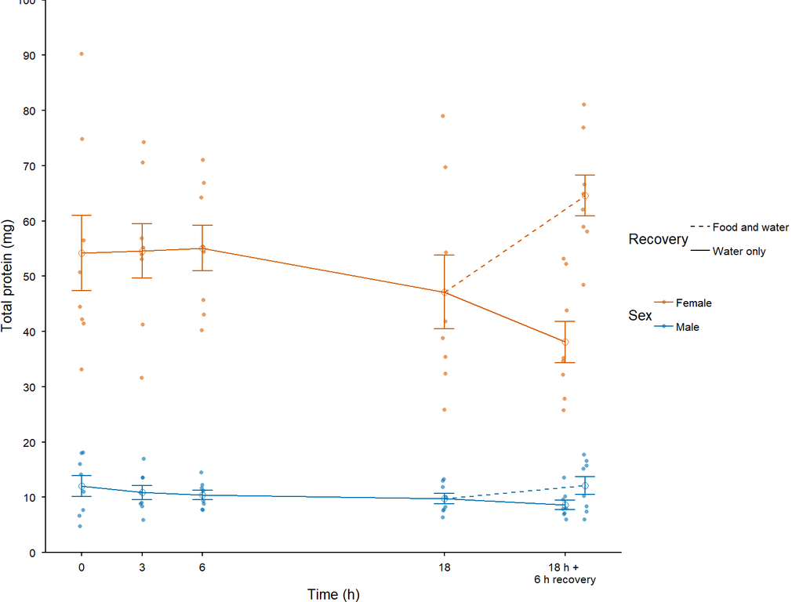

```r
p_total_protein <- ggplot() +
  geom_point(data = protein_data, aes(Time_plot, total_protein, shape = Sex, colour = Sex), position = position_jitter(width = 0.1, height = 0), alpha = 0.6, stroke = NA) +
   # line for starved crickets
  geom_line(data = mean_total_starved_p, aes(Time_plot, mean, colour = Sex, linetype = "Starved"), linewidth = 0.5) +
   # Line for fed crickets
  geom_line(data = mean_total_fed_p, aes(Time_plot, mean, colour = Sex, linetype = "Fed"), linewidth = 0.5) +
  geom_point(data = mean_total_protein, aes(Time_plot, mean, colour = Sex),
             size = 2, shape = 1, show.legend = FALSE) +
  geom_errorbar(data = mean_total_protein, aes(Time_plot, ymin = mean - se, ymax = mean + se,
                                     colour = Sex), width = 1, linewidth = 0.5) +
  scale_colour_manual(values = sex_pal) +
  scale_shape_manual(values = sex_point) +
  scale_linetype_manual(name = "Recovery", values = c("Fed" = 2, "Starved" = 1), labels = c("Food and water", "Water only")) +
  scale_y_continuous(name = "Total protein (mg)", limits = c(0, 100), expand = c(0,0), breaks = seq(0, 100, 10)) +
  scale_x_continuous(name = "Time (h)", breaks = c(0, 3, 6, 18, 24), labels = c("0", "3", "6", "18", "18 h + \n6 h recovery")) +
  theme(legend.position = "right")

p_total_protein
```

## 8.2 Plot: Protein per dry mass

```r
mean_protein <- protein_data %>%
  group_by(Time_treatment, Sex, Time, Time_plot) %>%
  drop_na(mg_protein_per_mg_tissue) %>%
  summarise(n = n(),
            mean = mean(mg_protein_per_mg_tissue),
            var = var(mg_protein_per_mg_tissue),
            se = sd(mg_protein_per_mg_tissue) / sqrt(n()),
            cv = (sd(mg_protein_per_mg_tissue) / mean) * 100)
knitr::kable(mean_protein, digits = 3)
```

| Time_treatment | Sex | Time | Time_plot | n | mean | var | se | cv |
| --- | --- | --- | --- | --- | --- | --- | --- | --- |
| 0 | Female | 0 | 0 | 8 | 0.254 | 0.003 | 0.021 | 23.074 |
| 0 | Male | 0 | 0 | 8 | 0.139 | 0.003 | 0.019 | 37.815 |
| 3 | Female | 3 | 3 | 8 | 0.272 | 0.002 | 0.014 | 14.944 |
| 3 | Male | 3 | 3 | 8 | 0.141 | 0.002 | 0.015 | 29.099 |
| 6 | Female | 6 | 6 | 8 | 0.242 | 0.001 | 0.013 | 14.904 |
| 6 | Male | 6 | 6 | 8 | 0.145 | 0.002 | 0.015 | 30.155 |
| 18 | Female | 18 | 18 | 8 | 0.281 | 0.006 | 0.027 | 27.285 |
| 18 | Male | 18 | 18 | 8 | 0.138 | 0.002 | 0.015 | 29.911 |
| 24_fed | Female | 24 | 25 | 8 | 0.256 | 0.003 | 0.019 | 20.459 |
| 24_fed | Male | 24 | 25 | 8 | 0.120 | 0.003 | 0.018 | 42.150 |
| 24_starved | Female | 24 | 24 | 8 | 0.249 | 0.001 | 0.011 | 12.885 |
| 24_starved | Male | 24 | 24 | 8 | 0.108 | 0.001 | 0.011 | 29.925 |

```r
mean_protein_starved <- filter(mean_protein, Time_treatment != "24_fed")
mean_protein_fed <- filter(mean_protein, Time_treatment %in% c("18", "24_fed"))
```

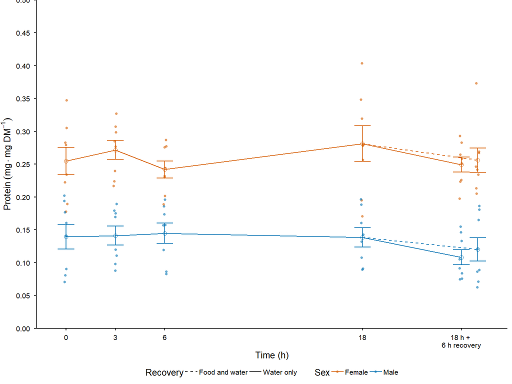

```r
p_protein <- ggplot() +
  geom_point(data = protein_data, aes(Time_plot, mg_protein_per_mg_tissue, shape = Sex, colour = Sex, group = Time_treatment), position = position_jitter(width = 0.1, height = 0), alpha = 0.6, stroke = NA) +
   # line for starved crickets
  geom_line(data = mean_protein_starved, aes(Time_plot, mean, colour = Sex, linetype = "Starved"), linewidth = 0.5) +
   # Line for fed crickets
  geom_line(data = mean_protein_fed, aes(Time_plot, mean, colour = Sex, linetype = "Fed"), linewidth = 0.5) +
  geom_point(data = mean_protein, aes(Time_plot, mean, colour = Sex, group = Time_treatment),
             size = 2, shape = 1, show.legend = FALSE) +
  geom_errorbar(data = mean_protein, aes(Time_plot, ymin = mean - se, ymax = mean + se,
                                     colour = Sex), width = 1, linewidth = 0.5) +
  scale_colour_manual(values = sex_pal) +
  scale_shape_manual(values = sex_point) +
  scale_linetype_manual(name = "Recovery", values = c("Fed" = 2, "Starved" = 1), labels = c("Food and water", "Water only")) +
  scale_y_continuous(name = expression("Protein" ~ ("mg"%.%"mg DM"^-1)), limits = c(0, 0.5), expand = c(0,0), breaks = seq(0, 100, 0.05)) +
  scale_x_continuous(name = "Time (h)", breaks = c(0, 3, 6, 18, 24), labels = c("0", "3", "6", "18", "18 h + \n6 h recovery"))

p_protein
```

```r
ggsave(p_protein, dpi = 300, width = ppt_width, units = "mm", height = ppt_height, filename = "data/Desiccation 2025/figures/tissue_proteins.png")
```

## 8.3 Stats: Total proteins

- Mixed model is singular - random effect dropped
- Three way interaction dropped
- Time:Sex is not significant, dropped

```r
# Random effect is singular - remove
full_p_mod <- lm(total_protein ~ Start_mass * Time_treatment * Sex, data = protein_data)

anova(full_p_mod)
```

```
Analysis of Variance Table

Response: total_protein
                              Df Sum Sq Mean Sq  F value                Pr(>F)
Start_mass                     1  43410   43410 583.9812 < 0.00000000000000022
Time_treatment                 5   2356     471   6.3400           0.000062549
Sex                            1   1964    1964  26.4247           0.000002263
Start_mass:Time_treatment      5    342      68   0.9211              0.472409
Start_mass:Sex                 1    727     727   9.7782              0.002548
Time_treatment:Sex             5     90      18   0.2412              0.942882
Start_mass:Time_treatment:Sex  5     89      18   0.2404              0.943269
Residuals                     72   5352      74

Start_mass                    ***
Time_treatment                ***
Sex                           ***
Start_mass:Time_treatment
Start_mass:Sex                **
Time_treatment:Sex
Start_mass:Time_treatment:Sex
Residuals
---
Signif. codes:  0 '***' 0.001 '**' 0.01 '*' 0.05 '.' 0.1 ' ' 1
```

```r
# Three way interaction is not significant

total_p_mod <- update(full_p_mod, .~. - Start_mass:Time_treatment:Sex)

total_p_mod <- update(total_p_mod, .~. -Time_treatment:Sex)

anova(total_p_mod)
```

```
Analysis of Variance Table

Response: total_protein
                          Df Sum Sq Mean Sq  F value                Pr(>F)
Start_mass                 1  43410   43410 643.5666 < 0.00000000000000022 ***
Time_treatment             5   2356     471   6.9869          0.0000175654 ***
Sex                        1   1964    1964  29.1209          0.0000006452 ***
Start_mass:Time_treatment  5    342      68   1.0151              0.414211
Start_mass:Sex             1    727     727  10.7759              0.001512 **
Residuals                 82   5531      67
---
Signif. codes:  0 '***' 0.001 '**' 0.01 '*' 0.05 '.' 0.1 ' ' 1
```

```r
best_p_mod <- step(full_p_mod)
```

```
Start:  AIC=434.01
total_protein ~ Start_mass * Time_treatment * Sex

                                Df Sum of Sq    RSS    AIC
- Start_mass:Time_treatment:Sex  5     89.35 5441.5 425.60
<none>                                       5352.1 434.01

Step:  AIC=425.6
total_protein ~ Start_mass + Time_treatment + Sex + Start_mass:Time_treatment +
    Start_mass:Sex + Time_treatment:Sex

                            Df Sum of Sq    RSS    AIC
- Time_treatment:Sex         5     89.64 5531.1 417.16
- Start_mass:Time_treatment  5    215.68 5657.2 419.33
<none>                                   5441.5 425.60
- Start_mass:Sex             1    599.11 6040.6 433.62

Step:  AIC=417.16
total_protein ~ Start_mass + Time_treatment + Sex + Start_mass:Time_treatment +
    Start_mass:Sex

                            Df Sum of Sq    RSS    AIC
<none>                                   5531.1 417.16
- Start_mass:Time_treatment  5    652.94 6184.1 417.88
- Start_mass:Sex             1    726.86 6258.0 427.02
```

```r
anova(best_p_mod)
```

```
Analysis of Variance Table

Response: total_protein
                          Df Sum Sq Mean Sq  F value                Pr(>F)
Start_mass                 1  43410   43410 643.5666 < 0.00000000000000022 ***
Time_treatment             5   2356     471   6.9869          0.0000175654 ***
Sex                        1   1964    1964  29.1209          0.0000006452 ***
Start_mass:Time_treatment  5    342      68   1.0151              0.414211
Start_mass:Sex             1    727     727  10.7759              0.001512 **
Residuals                 82   5531      67
---
Signif. codes:  0 '***' 0.001 '**' 0.01 '*' 0.05 '.' 0.1 ' ' 1
```

```r
pairs(emmeans(total_p_mod, ~ Time_treatment + Sex), adjust = "Tukey", by = "Sex") %>%
  broom::tidy() |>
  filter(adj.p.value <= 0.05)
```

```
# A tibble: 4 × 9
  Sex    term           contrast        null.value estimate std.error    df
  <chr>  <chr>          <chr>                <dbl>    <dbl>     <dbl> <dbl>
1 Female Time_treatment 3 - 24_starved           0 10.11983  2.983911    82
2 Female Time_treatment 18 - 24_starved          0 11.16684  3.244736    82
3 Male   Time_treatment 3 - 24_starved           0 10.11983  2.983911    82
4 Male   Time_treatment 18 - 24_starved          0 11.16684  3.244736    82
  statistic adj.p.value
      <dbl>       <dbl>
1  3.391466  0.01324129
2  3.441525  0.01138195
3  3.391466  0.01324129
4  3.441525  0.01138195
```

## 8.4 Stats: Protein per dry mass

- No interaction.
- No change over time, regardless of feeding state.

```r
protein_mod <- lmer(mg_protein_per_mg_tissue ~ Time_treatment + Sex + (1|Plate), protein_data)

anova(protein_mod)
```

```
Type III Analysis of Variance Table with Satterthwaite's method
                Sum Sq Mean Sq NumDF  DenDF  F value              Pr(>F)
Time_treatment 0.00649 0.00130     5 86.769   0.6576              0.6565
Sex            0.38624 0.38624     1 87.077 195.7549 <0.0000000000000002 ***
---
Signif. codes:  0 '***' 0.001 '**' 0.01 '*' 0.05 '.' 0.1 ' ' 1
```

# 9 Are crickets using carbohydrates?

Quality control: Plate 6 has degraded samples compared to the other plates because the box was kept at -20C for a week. Keep only three of the points and sample 96.

```r
# Join sample mass with metadata
carb_data <- read_excel("data/Desiccation 2025/Tissue water content/TissueWaterData.xlsx", sheet = "carb_sample_mass") %>%
  left_join(., tissue_data, by = "Cricket_ID") %>%
  mutate(Label = as.character(Label))

# Define the locations of the necessary files
carb_plate_map <- "data/desiccation 2025/tissue water content/carb_plate_map.xlsx"
carb_spec_folder <- "data/desiccation 2025/tissue water content/spec_folder/carb/"

# Get sample IDs for filtering data
list_sampleID_carb <- carb_data$Label %>% as.character() %>% list()

# Load plate metadata
list_map_carb <- carb_plate_map %>%
  # Get sheet names
  excel_sheets() %>%
  # Use sheet names to name the list
  set_names() %>%
  # Import each sheet into a list
  map(read_excel,
      path = carb_plate_map, range = "A1:L8", col_names = paste(1:12))

# Get list names for housekeeping
list_names_carb <- names(list_map_carb)

# Load absorbance data. Every file in the folder should be the an xlsx file.
list_spec_carb <- list.files(carb_spec_folder, full.names = TRUE) %>%
  # Import each file into a list
  map(read_excel, range = "B2:M9", col_names = paste(1:12), col_types = "numeric") %>%
  # Use file names to name the list
  setNames(list_names_carb)
```

```r
list_plate_carb <- map2(list_map_carb, list_spec_carb, f_plate) %>%  setNames(list_names_carb) # Uncorrected values

# Flag the deviant wells
list_plate_carb <- map(list_plate_carb, bad_well)
# Remove the deviant wells
list_plate_carb <- map(list_plate_carb, \(x) filter(x, bad_well == "OK")) %>% setNames(list_names_carb)
```

Correct for the blank

```r
list_corrected_plate_carb <- map(list_plate_carb, f_correction) %>% setNames(list_names_carb) # Averaged and corrected values
```

Fit model

```r
# Calculate standard curves
standard_curve_carb <- map2(list_corrected_plate_carb, list_sampleID_carb, f_standard_curve) %>% setNames(list_names_carb)
```

```r
# Calculate well concentrations
list_well_conc_carb <- pmap(list(list_corrected_plate_carb, standard_curve_carb, list_sampleID_carb), f_samples) %>%
  setNames(list_names_carb) %>%
  map2(., list(select(carb_data, Label, Tissue_dry_mass, Sample_mass)), \(assay, metadata) inner_join(assay, metadata, by = "Label"))
```

Check spikes:

```r
spike_meta <- data.frame(plate = c("plate1", "plate2", "plate3", "plate4", "plate5", rep("plate6", 8)),
                         standard_conc = 0.5,
                         spiked_ID =  str_subset(carb_data$Label, "spike"),
                         unspiked_ID = str_subset(carb_data$Label, "spike") %>% str_remove(., "spike")) %>%
  group_split(plate)


# Function of equation defined above
spike_recovery_fun <- function(assay, spike_metadata) {

spike_recovery <- ((assay[assay$Label %in% spike_metadata$spiked_ID,]$well_conc - assay[assay$Label  %in% spike_metadata$unspiked_ID,]$well_conc/2) / spike_metadata$standard_conc) * 100

spike_metadata$spike_recovery <- if(length(spike_recovery) != 0) {
  spike_recovery
  } else {NA}
  return(spike_metadata)
}

# Return spike recovery (%) as list in order of plates
spike_recovery <- map2(list_well_conc_carb, spike_meta, spike_recovery_fun) %>% list_rbind()
spike_recovery
```

```
# A tibble: 13 × 5
   plate  standard_conc spiked_ID unspiked_ID spike_recovery
   <chr>          <dbl> <chr>     <chr>                <dbl>
 1 plate1           0.5 spike88   88                35.77223
 2 plate2           0.5 spike94   94               127.4453
 3 plate3           0.5 spike65   65                50.34124
 4 plate4           0.5 spike33   33               117.8807
 5 plate5           0.5 spike15   15                51.83284
 6 plate6           0.5 spike9    9                 15.03206
 7 plate6           0.5 spike10   10                51.51243
 8 plate6           0.5 spike30   30                58.33454
 9 plate6           0.5 spike38   38                71.76334
10 plate6           0.5 spike39   39                51.51243
11 plate6           0.5 spike64   64                72.12240
12 plate6           0.5 spike75   75                53.23591
13 plate6           0.5 spike96   96                68.67544
```

- 0.25 mL of water added to pellet
- 0.5 mL supernatant extracted from initial digestion
- 1 mL of KOH added to dry tissue

```r
anthrone <- function(assay){
  assay$pellet_carb <- assay$well_conc * 0.25
  assay$sample_carb <- (assay$pellet_carb / 0.5) * 1
  assay$mg_carb_per_mg_tissue <- assay$sample_carb / assay$Sample_mass
  assay$total_carb <- assay$mg_carb_per_mg_tissue * assay$Tissue_dry_mass
  assay$carb_percent <- (assay$total_carb / assay$Tissue_dry_mass) * 100

  return(assay)
}

carb_content <- map(list_well_conc_carb, anthrone) %>% list_rbind(names_to = "Plate")
carb_data <- left_join(carb_data, carb_content, by = c("Label", "Sample_mass", "Tissue_dry_mass")) %>%
  filter(Include_for_carb == 1)
```

```r
mean_total_carb <- carb_data %>%
  group_by(Time_treatment, Sex, Time, Time_plot) %>%
  drop_na(total_carb) %>%
  summarise(n = n(),
            mean = mean(total_carb),
            se = sd(total_carb) / sqrt(n()),
            cv = (sd(total_carb) / mean) * 100)
knitr::kable(mean_total_carb, digits = 3)
```

| Time_treatment | Sex | Time | Time_plot | n | mean | se | cv |
| --- | --- | --- | --- | --- | --- | --- | --- |
| 0 | Female | 0 | 0 | 8 | 3.629 | 0.561 | 43.699 |
| 0 | Male | 0 | 0 | 8 | 1.408 | 0.186 | 37.414 |
| 3 | Female | 3 | 3 | 8 | 3.451 | 0.505 | 41.412 |
| 3 | Male | 3 | 3 | 8 | 1.435 | 0.201 | 39.597 |
| 6 | Female | 6 | 6 | 8 | 3.395 | 0.446 | 37.152 |
| 6 | Male | 6 | 6 | 8 | 1.336 | 0.262 | 55.526 |
| 18 | Female | 18 | 18 | 8 | 2.372 | 0.463 | 55.203 |
| 18 | Male | 18 | 18 | 8 | 0.908 | 0.068 | 21.104 |
| 24_fed | Female | 24 | 25 | 8 | 5.171 | 0.412 | 22.546 |
| 24_fed | Male | 24 | 25 | 8 | 1.484 | 0.161 | 30.681 |
| 24_starved | Female | 24 | 24 | 8 | 2.324 | 0.369 | 44.913 |
| 24_starved | Male | 24 | 24 | 8 | 0.886 | 0.096 | 30.649 |

```r
mean_total_starved_c <- filter(mean_total_carb, Time_treatment != "24_fed")
mean_total_fed_c <- filter(mean_total_carb, Time_treatment %in% c("18", "24_fed"))
```

## 9.1 Plot: Total carbs

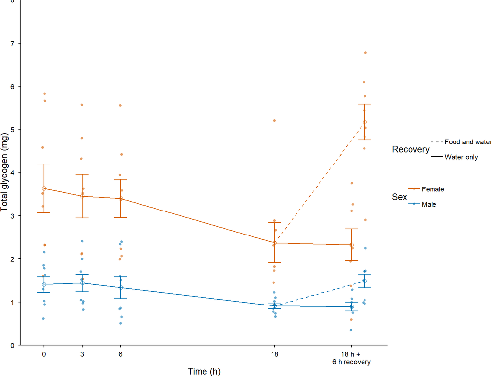

```r
p_total_carbs <- ggplot() +
  geom_point(data = carb_data, aes(Time_plot, total_carb, shape = Sex, colour = Sex), position = position_jitter(width = 0.1, height = 0), alpha = 0.6, stroke = NA) +
   # line for starved crickets
  geom_line(data = mean_total_starved_c, aes(Time_plot, mean, colour = Sex, linetype = "Starved"), linewidth = 0.5) +
   # Line for fed crickets
  geom_line(data = mean_total_fed_c, aes(Time_plot, mean, colour = Sex, linetype = "Fed"), linewidth = 0.5) +
  geom_point(data = mean_total_carb, aes(Time_plot, mean, colour = Sex),
             size = 2, shape = 1, show.legend = FALSE) +
  geom_errorbar(data = mean_total_carb, aes(Time_plot, ymin = mean - se, ymax = mean + se,
                                     colour = Sex), width = 1, linewidth = 0.5) +
  scale_colour_manual(values = sex_pal) +
  scale_shape_manual(values = sex_point) +
  scale_linetype_manual(name = "Recovery", values = c("Fed" = 2, "Starved" = 1), labels = c("Food and water", "Water only")) +
  scale_y_continuous(name = "Total glycogen (mg)", limits = c(0, 8), expand = c(0,0), breaks = seq(0, 100, 1)) +
  scale_x_continuous(name = "Time (h)", breaks = c(0, 3, 6, 18, 24), labels = c("0", "3", "6", "18", "18 h + \n6 h recovery")) +
  theme(legend.position = "right")

p_total_carbs
```

## 9.2 Plot: mg carb per mg dry mass

```r
mean_carb <- carb_data %>%
  group_by(Time_treatment, Sex, Time, Time_plot) %>%
  drop_na(mg_carb_per_mg_tissue) %>%
  summarise(n = n(),
            mean = mean(mg_carb_per_mg_tissue),
            var = var(mg_carb_per_mg_tissue),
            se = sd(mg_carb_per_mg_tissue) / sqrt(n()),
            cv = (sd(mg_carb_per_mg_tissue) / mean) * 100)
knitr::kable(mean_carb, digits = 3)
```

| Time_treatment | Sex | Time | Time_plot | n | mean | var | se | cv |
| --- | --- | --- | --- | --- | --- | --- | --- | --- |
| 0 | Female | 0 | 0 | 8 | 0.016 | 0 | 0.001 | 22.845 |
| 0 | Male | 0 | 0 | 8 | 0.016 | 0 | 0.002 | 32.619 |
| 3 | Female | 3 | 3 | 8 | 0.017 | 0 | 0.002 | 37.488 |
| 3 | Male | 3 | 3 | 8 | 0.018 | 0 | 0.002 | 30.109 |
| 6 | Female | 6 | 6 | 8 | 0.015 | 0 | 0.002 | 30.447 |
| 6 | Male | 6 | 6 | 8 | 0.017 | 0 | 0.003 | 48.058 |
| 18 | Female | 18 | 18 | 8 | 0.014 | 0 | 0.002 | 42.848 |
| 18 | Male | 18 | 18 | 8 | 0.013 | 0 | 0.002 | 35.175 |
| 24_fed | Female | 24 | 25 | 8 | 0.020 | 0 | 0.001 | 18.765 |
| 24_fed | Male | 24 | 25 | 8 | 0.015 | 0 | 0.002 | 32.539 |
| 24_starved | Female | 24 | 24 | 8 | 0.015 | 0 | 0.002 | 36.885 |
| 24_starved | Male | 24 | 24 | 8 | 0.011 | 0 | 0.001 | 29.843 |

```r
mean_carb_starved <- filter(mean_carb, Time_treatment != "24_fed")
mean_carb_fed <- filter(mean_carb, Time_treatment %in% c("18", "24_fed"))
```

> Coefficients of variation are similarly high for all treatments. No reason to suspect one group is biased.

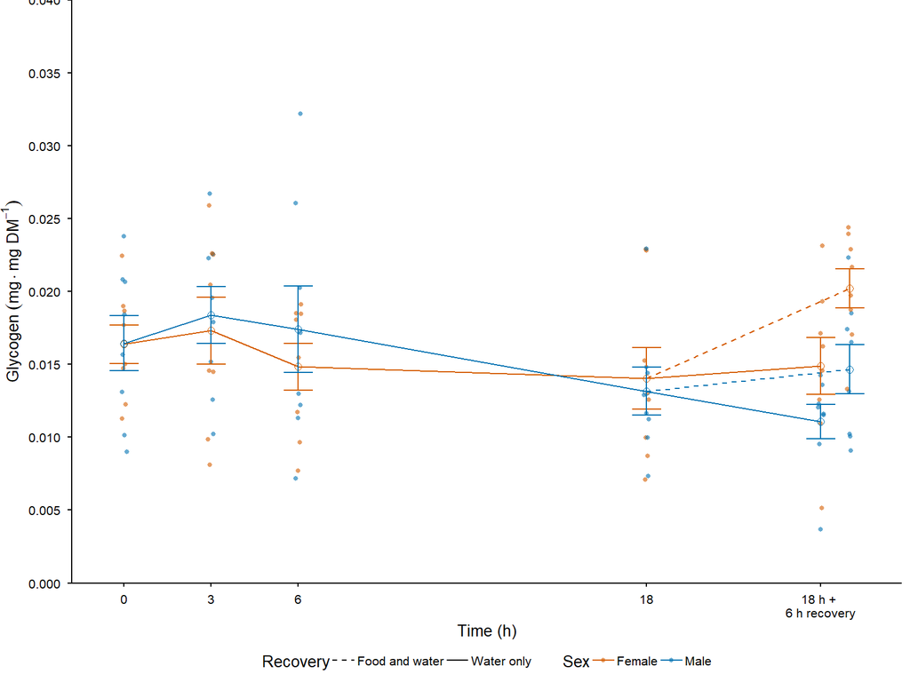

```r
p_carb <- ggplot() +
  geom_point(data = carb_data, aes(Time_plot, mg_carb_per_mg_tissue, shape = Sex, colour = Sex, group = Time_treatment), position = position_jitter(width = 0.1, height = 0), alpha = 0.6, stroke = NA) +
   # line for starved crickets
  geom_line(data = mean_carb_starved, aes(Time_plot, mean, colour = Sex, linetype = "Starved"), linewidth = 0.5) +
   # Line for fed crickets
  geom_line(data = mean_carb_fed, aes(Time_plot, mean, colour = Sex, linetype = "Fed"), linewidth = 0.5) +
  geom_point(data = mean_carb, aes(Time_plot, mean, colour = Sex, group = Time_treatment),
             size = 2, shape = 1, show.legend = FALSE) +
  geom_errorbar(data = mean_carb, aes(Time_plot, ymin = mean - se, ymax = mean + se,
                                     colour = Sex), width = 1, linewidth = 0.5) +
  scale_colour_manual(values = sex_pal) +
  scale_shape_manual(values = sex_point) +
  scale_linetype_manual(name = "Recovery", values = c("Fed" = 2, "Starved" = 1), labels = c("Food and water", "Water only")) +
  scale_y_continuous(name = expression("Glycogen" ~ ("mg"%.%"mg DM"^-1)), limits = c(0, 0.04), expand = c(0,0), breaks = seq(0, 100, 0.005)) +
  scale_x_continuous(name = "Time (h)", breaks = c(0, 3, 6, 18, 24), labels = c("0", "3", "6", "18", "18 h + \n6 h recovery"))

p_carb
```

```r
ggsave(p_carb, dpi = 300, width = ppt_width, units = "mm", height = ppt_height, filename = "data/Desiccation 2025/figures/tissue_carbs.png")
```

## 9.3 Stats: Total carbs

```r
full_c_mod <- lmer(total_carb ~ Start_mass * Time_treatment * Sex + (1|Plate), data = carb_data, REML = FALSE)

anova(full_c_mod)
```

```
Type III Analysis of Variance Table with Satterthwaite's method
                              Sum Sq Mean Sq NumDF  DenDF F value     Pr(>F)
Start_mass                    5.2273  5.2273     1 90.496 18.2004 0.00004881
Time_treatment                1.0556  0.2111     5 90.207  0.7351    0.59905
Sex                           0.9923  0.9923     1 90.732  3.4550    0.06630
Start_mass:Time_treatment     1.3845  0.2769     5 90.160  0.9641    0.44416
Start_mass:Sex                1.1386  1.1386     1 90.495  3.9644    0.04949
Time_treatment:Sex            1.3232  0.2646     5 89.800  0.9214    0.47096
Start_mass:Time_treatment:Sex 1.4454  0.2891     5 89.729  1.0065    0.41864

Start_mass                    ***
Time_treatment
Sex                           .
Start_mass:Time_treatment
Start_mass:Sex                *
Time_treatment:Sex
Start_mass:Time_treatment:Sex
---
Signif. codes:  0 '***' 0.001 '**' 0.01 '*' 0.05 '.' 0.1 ' ' 1
```

```r
# Three way interaction is not significant

best_c_mod <- step(full_c_mod, reduce.random = F)
print(best_c_mod)
```

```
Backward reduced random-effect table:

            Eliminated npar   logLik    AIC    LRT Df    Pr(>Chisq)
<none>                   26  -85.105 222.21
(1 | Plate)          0   25 -100.526 251.05 30.843  1 0.00000002798 ***
---
Signif. codes:  0 '***' 0.001 '**' 0.01 '*' 0.05 '.' 0.1 ' ' 1

Backward reduced fixed-effect table:
Degrees of freedom method: Satterthwaite

                              Eliminated Sum Sq Mean Sq NumDF  DenDF F value
Start_mass:Time_treatment:Sex          1 1.4454 0.28908     5 89.729  1.0065
Time_treatment:Sex                     2 0.4605 0.09210     5 90.172  0.3035
Start_mass:Time_treatment              3 2.0035 0.40071     5 89.789  1.2945
Time_treatment                         0 9.2969 1.85938     5 89.825  5.5740
Start_mass:Sex                         0 2.3840 2.38402     1 92.009  7.1468
                                 Pr(>F)
Start_mass:Time_treatment:Sex 0.4186402
Time_treatment:Sex            0.9096241
Start_mass:Time_treatment     0.2733514
Time_treatment                0.0001615 ***
Start_mass:Sex                0.0088853 **
---
Signif. codes:  0 '***' 0.001 '**' 0.01 '*' 0.05 '.' 0.1 ' ' 1

Model found:
total_carb ~ Start_mass + Time_treatment + Sex + (1 | Plate) + Start_mass:Sex
```

```r
# Model selection drops three way interaction
# Random term is significant

total_c_mod <- get_model(best_c_mod)
anova(total_c_mod)
```

```
Type III Analysis of Variance Table with Satterthwaite's method
               Sum Sq Mean Sq NumDF  DenDF F value     Pr(>F)
Start_mass     6.6012  6.6012     1 90.389 19.7891 0.00002457 ***
Time_treatment 9.2969  1.8594     5 89.825  5.5740  0.0001615 ***
Sex            1.7254  1.7254     1 92.700  5.1723  0.0252570 *
Start_mass:Sex 2.3840  2.3840     1 92.009  7.1468  0.0088853 **
---
Signif. codes:  0 '***' 0.001 '**' 0.01 '*' 0.05 '.' 0.1 ' ' 1
```

```r
pairs(emmeans(total_c_mod, ~ Time_treatment + Sex), adjust = "Tukey", by = "Sex") %>%
  broom::tidy() |>
  filter(adj.p.value <= 0.05)
```

```
# A tibble: 6 × 9
  Sex    term           contrast            null.value   estimate std.error
  <chr>  <chr>          <chr>                    <dbl>      <dbl>     <dbl>
1 Female Time_treatment 3 - 24_starved               0  0.7287799 0.2227636
2 Female Time_treatment 6 - 24_fed                   0 -0.7662007 0.2484913
3 Female Time_treatment 24_fed - 24_starved          0  1.019906  0.2352915
4 Male   Time_treatment 3 - 24_starved               0  0.7287799 0.2227636
5 Male   Time_treatment 6 - 24_fed                   0 -0.7662007 0.2484913
6 Male   Time_treatment 24_fed - 24_starved          0  1.019906  0.2352915
         df statistic  adj.p.value
      <dbl>     <dbl>        <dbl>
1  99.16604  3.271539 0.01792459
2 100.2380  -3.083410 0.03080609
3  99.30520  4.334650 0.0004912172
4  99.16604  3.271539 0.01792459
5 100.2380  -3.083410 0.03080609
6  99.30520  4.334650 0.0004912172
```

## 9.4 Stats: Carbs per dry mass

```r
carb_mod <- lmer(mg_carb_per_mg_tissue ~ Time_treatment + Sex + (1|Plate), carb_data)
anova(carb_mod)
```

```
Type III Analysis of Variance Table with Satterthwaite's method
                    Sum Sq     Mean Sq NumDF  DenDF F value  Pr(>F)
Time_treatment 0.000211832 0.000042366     5 84.030  2.4069 0.04325 *
Sex            0.000005845 0.000005845     1 84.744  0.3320 0.56598
---
Signif. codes:  0 '***' 0.001 '**' 0.01 '*' 0.05 '.' 0.1 ' ' 1
```

```r
pairs(emmeans(carb_mod, ~ Time_treatment), adjust = "Tukey")
```

```
 contrast              estimate      SE   df t.ratio p.value
 0 - 3               -0.0012832 0.00151 84.5  -0.851  0.9567
 0 - 6                0.0010736 0.00150 84.2   0.714  0.9798
 0 - 18               0.0011445 0.00151 84.5   0.759  0.9735
 0 - 24_fed          -0.0017951 0.00151 84.5  -1.191  0.8398
 0 - 24_starved       0.0025879 0.00152 84.7   1.697  0.5375
 3 - 6                0.0023568 0.00150 84.3   1.573  0.6185
 3 - 18               0.0024277 0.00151 84.3   1.604  0.5983
 3 - 24_fed          -0.0005119 0.00154 84.6  -0.333  0.9994
 3 - 24_starved       0.0038711 0.00152 84.4   2.551  0.1214
 6 - 18               0.0000709 0.00153 84.7   0.046  1.0000
 6 - 24_fed          -0.0028687 0.00155 84.9  -1.853  0.4380
 6 - 24_starved       0.0015143 0.00155 84.9   0.980  0.9232
 18 - 24_fed         -0.0029396 0.00151 84.4  -1.941  0.3850
 18 - 24_starved      0.0014433 0.00150 84.3   0.959  0.9294
 24_fed - 24_starved  0.0043830 0.00151 84.4   2.904  0.0516

Results are averaged over the levels of: Sex
Degrees-of-freedom method: kenward-roger
P value adjustment: tukey method for comparing a family of 6 estimates
```

```r
contrast(emmeans(carb_mod, ~ Time_treatment), method = "trt.vs.ctrl", ref = "0")
```

```
 contrast       estimate      SE   df t.ratio p.value
 3 - 0           0.00128 0.00151 84.5   0.851  0.8179
 6 - 0          -0.00107 0.00150 84.2  -0.714  0.8812
 18 - 0         -0.00114 0.00151 84.5  -0.759  0.8618
 24_fed - 0      0.00180 0.00151 84.5   1.191  0.6188
 24_starved - 0 -0.00259 0.00152 84.7  -1.697  0.3148

Results are averaged over the levels of: Sex
Degrees-of-freedom method: kenward-roger
P value adjustment: dunnettx method for 5 tests
```

# 10 Export data

```r
macros <- bind_cols(tissue_data,
          select(arrange(lipid_data, Cricket_ID), mg_lipid_per_mg_tissue, total_lipid, lipid_percent),
          select(arrange(protein_data, Cricket_ID), mg_protein_per_mg_tissue, total_protein, protein_percent),
          select(arrange(carb_data, Cricket_ID), mg_carb_per_mg_tissue, total_carb, carb_percent))
write.csv(macros, "data/Desiccation 2025/Tissue water content/macromolecule_results.csv")
save(lipid_data, protein_data, carb_data, file = "data/Desiccation 2025/Tissue water content/macromolecules.Rdata")
```

# 11 Conclusions

1. Are crickets losing haemolymph?

Yes, after 6 hours but both sexes restore the proportion of haemolymph after rehydration. This trend is also found in absolute haemolymph mass (mg).

2. Are crickets losing tissue water?

Even though crickets are losing wet mass throughout desiccation, they are maintaining the proportion of water in their tissue. Water is maintained even after using tissue (dry mass) at 18 hours.

Tissue wet mass increases during rehydration for starved crickets but this is an increase in fluid, not in tissue so tissue dry mass is unchanged. This indicates rehydration observed as an increase in % tissue water.

In fed crickets, water content does not differ to other time points, despite an increase in tissue dry mass (feed). Crickets are rehydrating but not over hydrating.

Thus, crickets are not losing tissue water and are increasing hydration state during recovery.

3. Are crickets using tissue?

Crickets do not appear to be using tissue at any time during desiccation.

Starved crickets are losing mass. This is likely an effect of starvation than desiccation. Fed crickets are gaining dry mass. Much of this mass is likely food in the gut.

4. Are crickets using their lipid stores?

Overall, crickets are using lipids after 24 hours, but this effect is not conserved within sex. This pattern is likely because of starvation.

This lack of a trend could be explained by crickets metabolising tissue, as indicated by their tissue dry mass. Thus, proportional amount of lipid in the tissue is the same because the overall amount of tissue is lowered.

Male crickets are not using lipid stores if they are starved, but are using lipid stores if they are fed. Could they be more active or less conservative if feed is available?

5. Are crickets using their protein stores?

Crickets are not using their protein stores. There is no difference between the amount of protein at 0 h and 18 h. Their total protein increases if they are fed, likely from the feed itself.

6. Are crickets using their carbohydrate stores?

> Crickets are able to tolerate and recover from desiccation. These tissue-level trends are more pronounced for females than males. Cricket are not losing dry mass during desiccation. Thus, there is limited support for using fat stores to aid recovery of water during desiccation.

> There is support for starved crickets to be using their macromolecules during recovery. Their dry mass decreases post-recovery mass with a higher water content and with a lower lipid content. They appear to be preferntially burning lipid over protein.